# 1. Implementing EM algorithm for MNIST dataset

Implement the EM algorithm for fitting a Gaussian mixture model for the MNIST dataset. We reduce the dataset to be only two cases, of digits "2" and "6" only. Thus, you will fit GMM with $C = 2$. Use the data file `data.mat` or `data.dat` on Canvas. True labels for the data are also provided in `label.mat` and `label.dat`.

The matrix `images` is of size 784 $\times$ 1990, i.e. there are 1990 images in total, and each column of the matrix corresponds to one image of size 28 $\times$ 28 pixels (the image is vectorized; the original image can be recovered by mapping the vector into a matrix.)

Hint: You may find the ntoes `speed-up-GMM.pdf` useful, which explains how to evaluate the density of a multivariate normal distribution. In this homework question, it is recommended you implement the evaluation of the Gaussian density this way, to avoid numerical issues.

## a. Visualize raw data

Select from the data one raw image of "2" and "6" and visualize them, respectively.

Below is a visualization of a "2" and "6" from images with indices 0 and 1032, respectively.

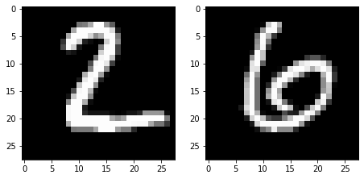

## b. Initialization and convergence

Use random Gaussian vector with zero mean as random initial means, and two identity matrices $I$ as initial covariance matrices for the clusters. Plot the log-likelihood function versus the number of iterations to show your algorithm is converging.

For my implementation, I applied the multivariate Gaussian density calculation from `speed-up-GMM.pdf`, which approximates $\Sigma$ using a low-rank approximation (with rank $r$).

Below are three plots showing the change in log-likelihood for different values of $r$.

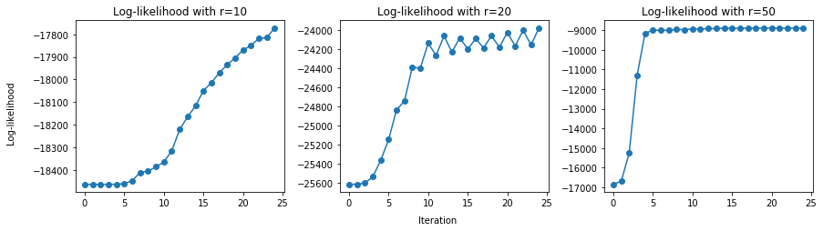

Note that the log-likelihood values are not exact; I excluded the constant $\sqrt{(2\pi)^d}$ because it is irrelevant for showing convergence.

## c. Fitted GMM model and mean vectors

Report the fitted GMM model when EM has terminated in your algorithms, including the weights for each component and the mean vectors (please reformat the vectors into 28 $\times$ 28 images and show these images in your submission). Ideally, you should be able to see these that means correspond to "average" images. No need to report the covariance matrices.

Below are the mean vectors (visualized) and component weights from three trials of my implementation of GMM.

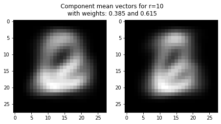

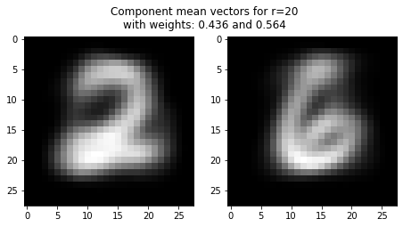

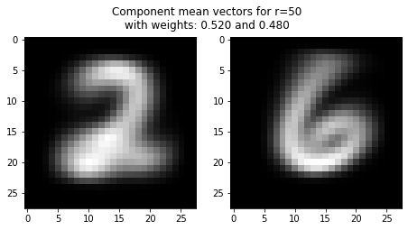

My observations:

- The subjective quality of the model increases with greater values of $r$. The "2" and "6" are both much clearer and more distinct in the final pair of images compared to the first.
- The weight assigned to the cluster associated with "2" increases with greater values of $r$. In particular, the final model assigns a weight of ~0.52 to the "2" cluster. This is close to the true proportion of "2"s in the dataset: 1,032 / 1,990 = 0.519

## d. GMM vs. K-means

Use the $p_{ic}$ to infer the labels of the images, and compare with the true labels. Report the misclassification rate for digits "2" and "6" respectively. Perform K-means clustering with $K = 2$ (you may call a package or use the code from your previous homework). Find out the misclassification rate for digits "2" and "6" respectively, and compare with GMM. Which one achieves better performance?

Using my final model generated with $r = 50$ and a limit of 25 iterations, I achieved a misclassification rate of:

- ~0.00954 (0.954%) for "2"s
- ~0.01055 (1.055%) for "6"s

Using scikit-learn's `KMeans` class, I achieved a misclassification rate of:

- ~0.02814 (2.814%) for "2"s
- ~0.03417 (3.417%) for "6"s

GMM achieves better performance than K-Means for this dataset.

# 2. Basic optimization

The background of logistic regression will be discussed in the next lecture. Here, we just focus on finding out the property of the optimization problem related to training a logistic regression.

Consider a simplified logistic regression problem given $m$ training samples $(x_i, y_i)$ with $i=1,\dots,n$ and the data $x_i \in \mathbb{R}$ and $y_i \in {0,1}$. To train/fit a logistic regression model for classification, we solve the following optimization problem, where $\theta \in \mathbb{R}$ is a parameter we aim to find:

$$\underset{\theta}{\text{max}} \ \ell(\theta),$$

where the log-likelihood function

$$\ell(\theta) = \sum_{i=1}^{n} \{-log(1 + exp\{-\theta x_i\}) + (y_i - 1)\theta x_i\}.$$

## a. Gradient descent

Derive the gradient of the cost function $\ell(\theta)$ and write **pseudo-code** for performing **gradient descent** to find the optimizer $\theta^*$. This is essentially what the training procedure does. Pseudo-code means you will write down the procedure in steps for the algorithm, not necessarily any specific programming language.

### Part 1: Derivation of cost function

$$\begin{align} \frac{\partial}{\partial \theta} \ell(\theta) & = \frac{\partial}{\partial \theta} \sum_{i=1}^{n} -log(1 + e^{-\theta x_i}) + (y_i - 1) \theta x_i \\ & = \sum_{i=1}^{n} - \frac{1}{1+e^{-\theta x_i}} \left(-x_i e^{-\theta x_i} \right) + (y_i - 1) x_i \\ & = \sum_{i=1}^{n} \frac{x_i e^{-\theta x_i}}{1 + e^{-\theta x_i}} + (y_i - 1) x_i \\ & = \sum_{i=1}^{n} x_i \left[ \frac{e^{-\theta x_i}}{1 + e^{-\theta x_i}} + (y_i - 1) \right] \\ & = \sum_{i=1}^{n} x_i \left[ \frac{1}{e^{\theta x_i}(1 + e^{-\theta x_i})} + (y_i - 1) \right] \\ & = \sum_{i=1}^{n} x_i \left[ \frac{1}{e^{\theta x_i} + 1} + (y_i - 1) \right] \end{align}$$

### Part 2: Gradient descent

Below is pseudo-code for a gradient descent algorithm. The algorithm starts with an empty/zero vector of parameter values and updates those values by incrementally taking small steps in the direction of the gradient.

Once the updated values are no longer very different from the values in the previous iteration, the algorithm stops.

```python
theta_current = [0, ..., 0]  # Initialize parameters as a zero vector of length J
theta_new = [0, ..., 0]
tolerance = 1e-06  # Some small value when the algorithm can stop
step_size = 1e-02  # Amount to move in direction of gradient

while True:
    theta_current = theta_new
    gradients = [0, ..., 0]  # Initialize gradients as a zero vector of length J

    # Calculate gradients (partial derivatives for each parameter)
    for j in range(J):
        for i in range(N):
            gradients[j] += X[i,j] * (1 / (exp(theta[j] * X[i,j]) + 1) + (y[i] - 1))

    # Update parameter values with a step in the direction of the gradient
    for j in range(J):
        theta_new[j] = theta_current[j] + step_size * gradients[j]

    # Calculate difference (distance) between theta parameter vectors
    sum_of_sq = 0
    for j in range(J):
        sum_of_sq += (theta_new[j] - theta_current[j])**2

    theta_diff = sqrt(sum_of_sq)  # Euclidean distance

    # Stop if the algorithm has converged
    if theta_diff < tolerance:
        break

return theta_new
```

## b. Stochastic gradient descent

Write down a **stochastic gradient descent** algorithm to solve the training of the logistic regression problem (1).

In stochastic gradient descent, we iterate through a **subset** of data points when calculating gradients instead of iterating through all data points. The subset is a random sample. Each subset is chosen without replacement, and the indices of the selected data points are stored so that all data points are eventually used.

The algorithm is essentially the same as deterministic gradient descent, except that logic is added to randomly sample a subset of data points.

```python
theta_current = [0, ..., 0]  # Initialize parameters as a zero vector of length J
theta_new = [0, ..., 0]
tolerance = 1e-06  # Some small value when the algorithm can stop
step_size = 1e-02  # Amount to move in direction of gradient
data_sampled = []  # Data already sampled in the algorithm
batch_size = 64  # Some number of data points to sample in each iteration
data_indices = [0, ..., n]  # List of data point indices for sampling

while True:
    theta_current = theta_new
    gradients = [0, ..., 0]  # Initialize gradients as a zero vector of length J
    available_data = data_indices - data_sampled  # Only sample from unseen data
    data_to_sample = random.choice(available_data, size=batch_size, replace=False)

    # Calculate gradients (partial derivatives for each parameter)
    for j in range(J):
        for i in data_to_sample:  # Calculate only for selected sample of data
            gradients[j] += X[i,j] * (1 / (exp(theta[j] * X[i,j]) + 1) + (y[i] - 1))

    # Update parameter values with a step in the direction of the gradient
    for j in range(J):
        theta_new[j] = theta_current[j] + step_size * gradients[j]

    # Calculate difference (distance) between theta parameter vectors
    sum_of_sq = 0
    for j in range(J):
        sum_of_sq += (theta_new[j] - theta_current[j])**2

    theta_diff = sqrt(sum_of_sq)  # Euclidean distance

    data_sampled.append(data_to_sample)  # Update list of data already sampled

    # Stop if the algorithm has converged
    if theta_diff < tolerance:
        break

return theta_new
```

## c. Show concavity of the training problem

**Show that the training problem in basic logistic regression is concave.** Derive the Hessian matrix of $\ell(\theta)$ and based on this, show the training problem (1) is concave. Explain why the problem can be solved efficiently and gradient descent will achieve a unique global optimizer, as we discussed in the lecture.

### Part 1: Hessian and concavity

$$\begin{align} \frac{\partial^2}{\partial \theta^2} \ell(\theta) & = \frac{\partial}{\partial \theta} \sum_{i=1}^{n} \frac{x_i e^{-\theta x_i}}{1 + e^{-\theta x_i}} + (y_i - 1) x_i \\ & = \sum_{i=1}^{n} \frac{\partial}{\partial \theta} \left[ \frac{x_i e^{-\theta x_i}}{1 + e^{-\theta x_i}} \right] + \sum_{i=1}^{n} \frac{\partial}{\partial \theta} \left[ (y_i - 1) x_i \right] \\ & = \sum_{i=1}^{n} \frac{\partial}{\partial \theta} \left[ \frac{x_i e^{-\theta x_i}}{1 + e^{-\theta x_i}} \right] + 0 \\ & = \sum_{i=1}^{n} \frac{\partial}{\partial \theta} \left[ \frac{x_i}{e^{\theta x_i}(1 + e^{-\theta x_i})} \right] \\ & = \sum_{i=1}^{n} \frac{\partial}{\partial \theta} \left[ \frac{x_i}{1 + e^{\theta x_i}} \right] \\ & = \sum_{i=1}^{n} \frac{\partial}{\partial \theta} \left[ x_i(1 + e^{\theta x_i})^{-1} \right] \\ & = \sum_{i=1}^{n} -x_i(1 + e^{\theta x_i})^{-2}(e^{\theta x_i}x_i) \\ & = -\sum_{i=1}^{n} \frac{x_i^2 e^{\theta x_i}}{(1 + e^{\theta x_i})^2} \end{align}$$

The Hessian is negative everywhere because every term inside the summation is positive:

- $x_i^2 \geq 0$
- $e^{\theta x_i} \gt 0$ since the range of the exponential function is $\gt 0$

Then, we take the **negative** of the summation, making the Hessian negative everywhere (negative definite). Because the Hessian (second derivative) is negative definite, the cost function $\ell(\theta)$ in the training problem is concave. This is the second-order condition of concavity.

### Part 2: Explanation of efficiency

Our cost function is concave; however, **it can be stated as a convex optimization problem** by minimizing its negative:

$$ \underset{\theta}{\text{max}} \ \ell(\theta) = \underset{\theta}{\text{min}} \ -\ell(\theta) $$

A convex optimization problem has the property that any local optimum is also a global optimum. This means that we can find a numerical optimum by checking for convergence (when the difference between iterative $\theta$ values becomes very small) and accept that as our global optimum.